# Modelowanie i prognozowanie cen gazu TTF

Analiza ekonometryczna: ARIMA + GARCH

Maciek Gilecki, Wioletta Grabias

03.05.2026

# 1 Wprowadzenie

## 1.1 Kontekst ekonomiczny

Title Transfer Facility (TTF) to holenderski wirtualny hub gazowy — główny benchmark cen gazu ziemnego w Europie. Notowania wyrażane są w EUR/MWh i odzwierciedlają równowagę popytu i podaży na rynku europejskim. Dynamika cen TTF jest determinowana przez czynniki popytowe (temperatura, aktywność przemysłowa), podażowe (zapasy magazynowe, dostawy rurociągowe, import LNG), makroekonomiczne (kurs EUR/USD, ceny ropy Brent) oraz geopolityczne (konflikty, sankcje, decyzje regulatoryjne).

Szczególnym przypadkiem był rok 2022, gdy odcięcie dostaw z Rosji doprowadziło do wzrostu cen TTF do ponad 300 EUR/MWh (sierpień 2022) i dramatycznego wzrostu zmienności szeregu czasowego.

## 1.2 Mechanizm rynku — analiza popytu i podaży

Klasyczna analiza mikroekonomiczna pozwala zilustrować, jak szoki popytowe i podażowe wpływają na cenę równowagi rynkowej oraz wolumen obrotu gazem. Krzywa popytu $D$ jest opadająca (wraz ze wzrostem ceny ilość zapotrzebowania maleje), krzywa podaży $S$ jest rosnąca. Punkt przecięcia wyznacza cenę równowagi $P^*$ oraz wolumen $Q^*$.

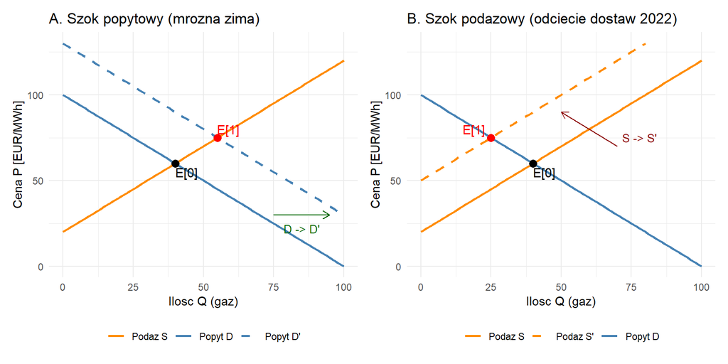

Wpływ szoków popytowych i podażowych na rynek gazu TTF

**Interpretacja:**

- **Panel A (szok popytowy)**: mroźna zima zwiększa zapotrzebowanie na gaz przy każdej cenie. Krzywa $D$ przesuwa się w prawo do $D'$. Nowa równowaga $E_1$ charakteryzuje się *wyższą ceną* oraz *wyższym wolumenem*.
- **Panel B (szok podażowy)**: odcięcie dostaw rurociągowych z Rosji w 2022 r. zmniejszyło dostępną podaż przy każdej cenie. Krzywa $S$ przesuwa się w lewo (w górę) do $S'$. Nowa równowaga $E_1$ charakteryzuje się *wyższą ceną* przy *niższym wolumenie* — ten przypadek odpowiada faktycznej dynamice cen TTF w 2022 r.

W praktyce na rynku TTF szoki podażowe i popytowe nakładają się na siebie, a powrót do równowagi następuje przez kanały adaptacyjne: substytucję paliw, import LNG, ograniczenie zużycia przemysłowego.

## 1.3 Cel projektu

Celem projektu jest:

- Zbudowanie modelu **ARIMA** prognozującego warunkową średnią cen TTF.
- Weryfikacja efektu ARCH w resztach modelu.
- Estymacja modelu **GARCH** modelującego warunkową wariancję (zmienność).
- Diagnostyka oraz prognoza punktowa i przedziałowa.

## 1.4 Hipotezy badawcze

- **H1**: Szereg cen TTF jest niestacjonarny i wymaga różnicowania.
- **H2**: W resztach modelu ARIMA występuje efekt ARCH.
- **H3**: Model GARCH lepiej oddaje strukturę zmienności niż klasyczne ARIMA.

# 2 Wczytanie i przygotowanie danych

## 2.1 Źródło danych

Dane wykorzystane w analizie pochodzą z platformy Kaggle, dataset *Dutch TTF Natural Gas Futures Historical Dataset* udostępniony przez Arushi Rawat:

https://www.kaggle.com/datasets/arushirawat/dutch-ttf-natural-gas-futures-historical-dataset Pierwotnym źródłem notowań jest **Investing.com**, agregujący dane z giełdy ICE Endex (kontrakty futures na gaz TTF). Dataset zawiera historyczne notowania dzienne kontraktu pierwszego (*front-month futures*) wyrażone w EUR/MWh.

**Struktura pliku CSV:**

- `Date` — data sesji giełdowej
- `Price` — cena zamknięcia [EUR/MWh] — **zmienna analizowana**
- `Open, High, Low` — ceny otwarcia, maksimum, minimum sesji
- `Vol.` — wolumen obrotu
- `Change %` — zmiana procentowa względem poprzedniej sesji

W projekcie wykorzystywana jest wyłącznie kolumna `Price` jako zmienna zależna oraz `Date` jako indeks czasowy.

```r
# Wczytanie surowych danych
ttf_raw <- read.csv("data/ttf.csv", stringsAsFactors = FALSE)

# Podgląd struktury
str(ttf_raw)
```

```
## 'data.frame':    1790 obs. of  7 variables:
##  $ Date    : chr  "29/11/2024" "28/11/2024" "27/11/2024" "26/11/2024" ...
##  $ Price   : num  47.4 46.8 46.8 47.2 47.7 ...
##  $ Open    : num  46.5 47.5 46.5 47.4 47.7 ...
##  $ High    : num  47.9 47.5 46.8 48.3 48.9 ...
##  $ Low     : num  46.2 46.6 46 46.1 47.4 ...
##  $ Vol.    : chr  "0.54K" "0.13K" "0.09K" "0.19K" ...
##  $ Change..: chr  "1.23%" "0.03%" "-0.96%" "-1.08%" ...
```

```r
head(ttf_raw)
```

|  | Date | Price | Open | High | Low | Vol. | Change.. |
| --- | --- | --- | --- | --- | --- | --- | --- |
| 1 | 29/11/2024 | 47.350 | 46.450 | 47.945 | 46.235 | 0.54K | 1.23% |
| 2 | 28/11/2024 | 46.775 | 47.480 | 47.480 | 46.640 | 0.13K | 0.03% |
| 3 | 27/11/2024 | 46.762 | 46.535 | 46.800 | 46.000 | 0.09K | -0.96% |
| 4 | 26/11/2024 | 47.216 | 47.380 | 48.290 | 46.130 | 0.19K | -1.08% |
| 5 | 25/11/2024 | 47.733 | 47.665 | 48.880 | 47.400 | 0.67K | 1.52% |
| 6 | 22/11/2024 | 47.018 | 49.050 | 49.240 | 46.775 | 10.60K | -2.66% |

```r
# UWAGA: Kaggle używa formatu daty "MM/DD/YYYY" lub "DD-MM-YYYY"
# oraz kolumna ceny nazywa się "Price" (nie "Close"). Adaptujemy parser.

# Wyznacz nazwę kolumny ceny (Close lub Price)
price_col <- if ("Close" %in% names(ttf_raw)) "Close" else "Price"

ttf <- ttf_raw %>%
  rename(Price = !!price_col) %>%
  mutate(
    # Próba parsowania kilku popularnych formatów daty
    Date = suppressWarnings(parse_date_time(
      Date, orders = c("mdy", "dmy", "ymd", "Y-m-d", "m/d/Y", "d/m/Y")
    )),
    Date = as.Date(Date),
    # Usuwamy ewentualne przecinki w cenie (Kaggle czasem ma "1,234.56")
    Price = as.numeric(gsub(",", "", as.character(Price)))
  ) %>%
  select(Date, Price) %>%
  filter(!is.na(Price), !is.na(Date)) %>%
  arrange(Date) %>%
  distinct(Date, .keep_all = TRUE)

cat("Zakres dat:", as.character(min(ttf$Date)), "-",
    as.character(max(ttf$Date)), "\n")
```

```
## Zakres dat: 2017-10-23 - 2024-11-29
```

```r
cat("Liczba obserwacji:", nrow(ttf), "\n")
```

```
## Liczba obserwacji: 1790
```

```r
cat("Liczba braków:", sum(is.na(ttf$Price)), "\n")
```

```
## Liczba braków: 0
```

```r
# Statystyki opisowe
summary_stats <- ttf %>%
  summarise(
    Srednia    = mean(Price),
    Mediana    = median(Price),
    Odch_std   = sd(Price),
    Min        = min(Price),
    Max        = max(Price),
    Skosnosc   = moments::skewness(Price),
    Kurtoza    = moments::kurtosis(Price)
  )

kable(summary_stats, digits = 2,
      caption = "Statystyki opisowe szeregu cen TTF",
      booktabs = TRUE)
```

Statystyki opisowe szeregu cen TTF

| Srednia | Mediana | Odch_std | Min | Max | Skosnosc | Kurtoza |
| --- | --- | --- | --- | --- | --- | --- |
| 42.62 | 26.01 | 45.43 | 3.51 | 339.2 | 2.43 | 9.73 |

# 3 Analiza eksploracyjna (EDA)

## 3.1 Wykres szeregu czasowego

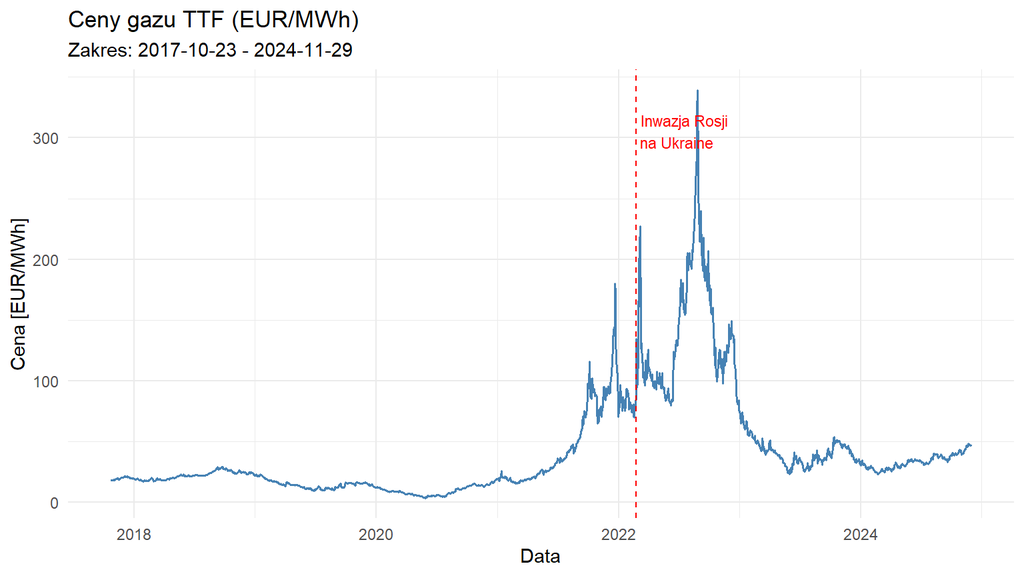

Ceny gazu TTF w okresie objętym analizą

```r
ggplot(ttf, aes(x = Date, y = Price)) +
  geom_line(color = "steelblue", linewidth = 0.6) +
  labs(title = "Ceny gazu TTF (EUR/MWh)",
       subtitle = paste("Zakres:", min(ttf$Date), "-", max(ttf$Date)),
       x = "Data", y = "Cena [EUR/MWh]") +
  geom_vline(xintercept = as.Date("2022-02-24"),
             linetype = "dashed", color = "red") +
  annotate("text", x = as.Date("2022-02-24"),
           y = max(ttf$Price) * 0.9,
           label = "Inwazja Rosji\nna Ukraine",
           hjust = -0.05, color = "red", size = 3)
```

## 3.2 Logarytmiczne stopy zwrotu

W ekonometrii finansowej standardowo modelujemy logarytmiczne stopy zwrotu:
$$r_t = \ln(P_t) -
\ln(P_{t-1})$$

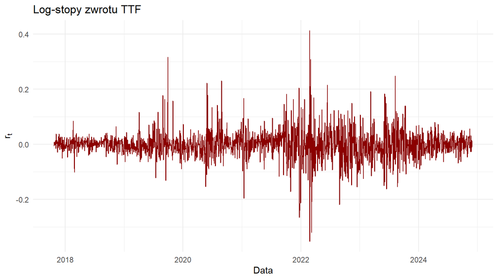

Logarytmiczne stopy zwrotu TTF — widoczne klastry zmienności

```r
ttf <- ttf %>%
  mutate(
    log_price = log(Price),
    log_ret   = c(NA, diff(log_price))
  )

returns_xts <- xts::xts(ttf$log_ret[-1], order.by = ttf$Date[-1])
returns <- as.numeric(returns_xts)

ggplot(filter(ttf, !is.na(log_ret)), aes(x = Date, y = log_ret)) +
  geom_line(color = "darkred", linewidth = 0.4) +
  labs(title = "Log-stopy zwrotu TTF",
       x = "Data", y = expression(r[t]))
```

```r
ret_stats <- data.frame(
  Srednia            = mean(returns),
  Odch_std           = sd(returns),
  Min                = min(returns),
  Max                = max(returns),
  Skosnosc           = moments::skewness(returns),
  Kurtoza_nadwyzkowa = moments::kurtosis(returns) - 3,
  JB_pvalue          = jarque.bera.test(returns)$p.value
)

kable(ret_stats, digits = 4,
      caption = "Statystyki log-stóp zwrotu",
      booktabs = TRUE)
```

Statystyki log-stóp zwrotu

| Srednia | Odch_std | Min | Max | Skosnosc | Kurtoza_nadwyzkowa | JB_pvalue |
| --- | --- | --- | --- | --- | --- | --- |
| 5e-04 | 0.0526 | -0.3524 | 0.4128 | 0.378 | 7.5557 | 0 |

Wysoka kurtoza nadwyżkowa ($>0$) wskazuje na ,,grube ogony’’ rozkładu — typowe dla szeregów finansowych. Test Jarque-Bera odrzuca hipotezę normalności.

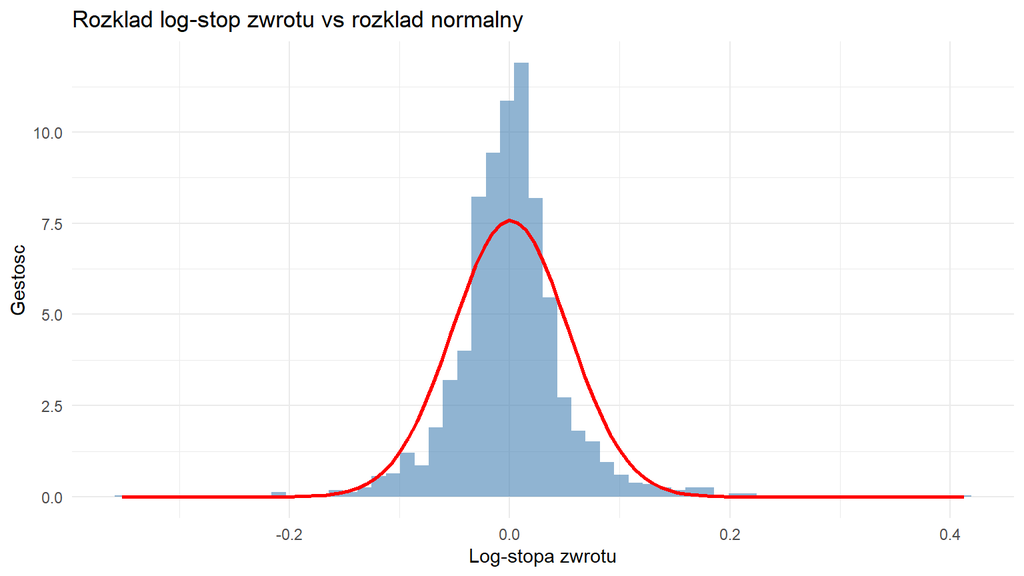

Rozkład log-stóp zwrotu TTF z nałożoną gęstością normalną

```r
ggplot(data.frame(r = returns), aes(x = r)) +
  geom_histogram(aes(y = after_stat(density)), bins = 60,
                 fill = "steelblue", alpha = 0.6) +
  stat_function(fun = dnorm,
                args = list(mean = mean(returns), sd = sd(returns)),
                color = "red", linewidth = 1) +
  labs(title = "Rozklad log-stop zwrotu vs rozklad normalny",
       x = "Log-stopa zwrotu", y = "Gestosc")
```

# 4 Test stacjonarności

## 4.1 Augmented Dickey-Fuller (ADF)

$H_0$: szereg jest niestacjonarny (jednostkowy pierwiastek).

```r
adf_price <- adf.test(ttf$Price)
print(adf_price)
```

```
##
##  Augmented Dickey-Fuller Test
##
## data:  ttf$Price
## Dickey-Fuller = -2.1346, Lag order = 12, p-value = 0.5213
## alternative hypothesis: stationary
```

```r
adf_ret <- adf.test(returns)
print(adf_ret)
```

```
##
##  Augmented Dickey-Fuller Test
##
## data:  returns
## Dickey-Fuller = -12.565, Lag order = 12, p-value = 0.01
## alternative hypothesis: stationary
```

## 4.2 KPSS

$H_0$: szereg jest stacjonarny (komplementarny do ADF).

```r
kpss_price <- kpss.test(ttf$Price)
print(kpss_price)
```

```
##
##  KPSS Test for Level Stationarity
##
## data:  ttf$Price
## KPSS Level = 4.9346, Truncation lag parameter = 8, p-value = 0.01
```

```r
kpss_ret <- kpss.test(returns)
print(kpss_ret)
```

```
##
##  KPSS Test for Level Stationarity
##
## data:  returns
## KPSS Level = 0.1159, Truncation lag parameter = 8, p-value = 0.1
```

**Wniosek:** Ceny są niestacjonarne. Po pierwszym różnicowaniu (log-stopy zwrotu) szereg staje się stacjonarny. Stosujemy zatem $d=1$ w modelu ARIMA.

# 5 Identyfikacja modelu ARIMA

## 5.1 ACF i PACF

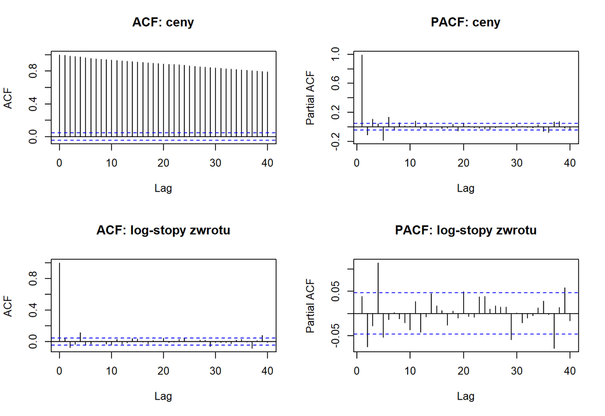

Funkcje ACF i PACF dla cen oraz log-stóp zwrotu

```r
par(mfrow = c(2, 2))
acf(ttf$Price,  main = "ACF: ceny", lag.max = 40)
pacf(ttf$Price, main = "PACF: ceny", lag.max = 40)
acf(returns,    main = "ACF: log-stopy zwrotu", lag.max = 40)
pacf(returns,   main = "PACF: log-stopy zwrotu", lag.max = 40)
```

```r
par(mfrow = c(1, 1))
```

# 6 Estymacja modelu ARIMA

## 6.1 Auto-ARIMA

```r
fit_auto <- auto.arima(
  ttf$Price,
  d = 1,
  seasonal = FALSE,
  stepwise = FALSE,
  approximation = FALSE,
  trace = FALSE,
  ic = "aicc"
)

summary(fit_auto)
```

```
## Series: ttf$Price
## ARIMA(1,1,4)
##
## Coefficients:
##           ar1     ma1     ma2      ma3     ma4
##       -0.5764  0.7397  0.0058  -0.1429  0.1198
## s.e.   0.0730  0.0755  0.0327   0.0323  0.0324
##
## sigma^2 = 24.29:  log likelihood = -5389.59
## AIC=10791.18   AICc=10791.23   BIC=10824.12
##
## Training set error measures:
##                      ME     RMSE      MAE         MPE     MAPE     MASE
## Training set 0.01478049 4.919995 2.056014 -0.07153004 3.653905 1.011282
##                     ACF1
## Training set 0.001864532
```

## 6.2 Modele kandydujące — porównanie AIC/BIC

```r
grid <- expand.grid(p = 0:3, d = 1, q = 0:3)

results <- grid %>%
  rowwise() %>%
  mutate(
    fit = list(tryCatch(
      Arima(ttf$Price, order = c(p, d, q)),
      error = function(e) NULL
    )),
    AIC = ifelse(is.null(fit), NA, AIC(fit)),
    BIC = ifelse(is.null(fit), NA, BIC(fit))
  ) %>%
  select(-fit) %>%
  arrange(AIC)

kable(head(results, 10), digits = 2,
      caption = "10 najlepszych modeli ARIMA wg AIC",
      booktabs = TRUE)
```

10 najlepszych modeli ARIMA wg AIC

| p | d | q | AIC | BIC |
| --- | --- | --- | --- | --- |
| 3 | 1 | 2 | 10794.14 | 10827.08 |
| 2 | 1 | 3 | 10794.92 | 10827.86 |
| 1 | 1 | 3 | 10801.77 | 10829.22 |
| 3 | 1 | 3 | 10801.94 | 10840.36 |
| 3 | 1 | 1 | 10839.84 | 10867.29 |
| 2 | 1 | 2 | 10860.14 | 10887.58 |
| 0 | 1 | 3 | 10875.90 | 10897.86 |
| 3 | 1 | 0 | 10896.03 | 10917.99 |
| 2 | 1 | 0 | 10897.96 | 10914.43 |
| 2 | 1 | 1 | 10898.99 | 10920.95 |

## 6.3 Diagnostyka reszt

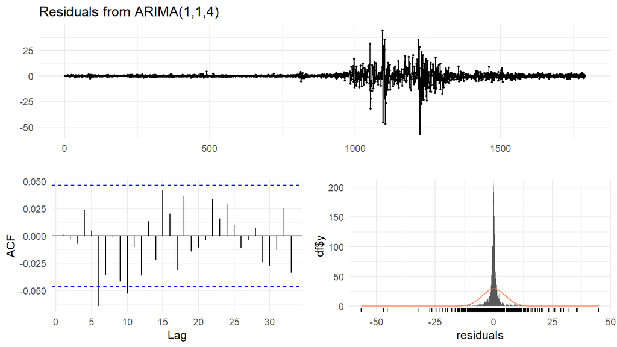

Diagnostyka reszt modelu ARIMA

```
##
##  Ljung-Box test
##
## data:  Residuals from ARIMA(1,1,4)
## Q* = 19.21, df = 5, p-value = 0.001756
##
## Model df: 5.   Total lags used: 10
```

```r
fit_arima   <- fit_auto
arima_resid <- residuals(fit_arima)

checkresiduals(fit_arima)
```

```r
# Ljung-Box (autokorelacja reszt)
lb <- Box.test(arima_resid, lag = 20, type = "Ljung-Box",
               fitdf = sum(fit_arima$arma[1:2]))
print(lb)
```

```
##
##  Box-Ljung test
##
## data:  arima_resid
## X-squared = 31.722, df = 15, p-value = 0.007024
```

```r
# Jarque-Bera (normalność reszt)
jb <- jarque.bera.test(arima_resid)
print(jb)
```

```
##
##  Jarque Bera Test
##
## data:  arima_resid
## X-squared = 79383, df = 2, p-value < 2.2e-16
```

**Wnioski z diagnostyki:**

- **Ljung-Box** ($p < 0.05$): odrzucamy hipotezę o braku autokorelacji w resztach. Resztki ARIMA wykazują pozostałą strukturę zależności — jest to typowe dla szeregów finansowych z silną heteroskedastycznością warunkową (efekty ARCH wpływają również na statystykę Ljung-Boxa).
- **Jarque-Bera** ($p < 0.05$): reszty nie pochodzą z rozkładu normalnego (grube ogony) — uzasadnia zastosowanie rozkładu t-Studenta w specyfikacji modelu GARCH.
- **Wykres reszt**: wyraźnie widoczne klastry zmienności (szczególnie w okresie 2021–2023) — silna przesłanka do testu ARCH-LM i modelu GARCH.

# 7 Test efektu ARCH

$H_0$: brak efektu ARCH (jednorodność warunkowej wariancji).

```r
arch_test <- ArchTest(arima_resid, lags = 12)
print(arch_test)
```

```
##
##  ARCH LM-test; Null hypothesis: no ARCH effects
##
## data:  arima_resid
## Chi-squared = 528.75, df = 12, p-value < 2.2e-16
```

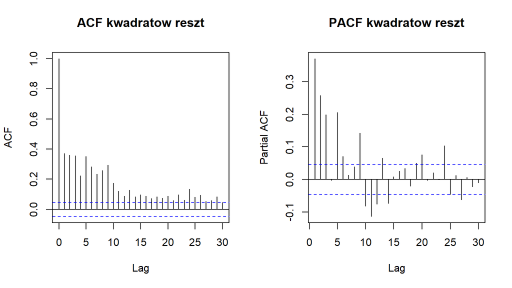

ACF i PACF kwadratów reszt ARIMA

```r
par(mfrow = c(1, 2))
acf(arima_resid^2,  main = "ACF kwadratow reszt",  lag.max = 30)
pacf(arima_resid^2, main = "PACF kwadratow reszt", lag.max = 30)
```

```r
par(mfrow = c(1, 1))
```

Jeśli $p < 0.05$, odrzucamy $H_0$, co oznacza obecność efektu ARCH i uzasadnia zastosowanie modelu GARCH.

# 8 Estymacja modelu GARCH

## 8.1 Specyfikacja GARCH(1,1) z błędem t-Studenta

```r
arma_order <- c(fit_arima$arma[1], fit_arima$arma[2])

garch_spec <- ugarchspec(
  variance.model = list(model = "sGARCH", garchOrder = c(1, 1)),
  mean.model     = list(armaOrder = arma_order, include.mean = TRUE),
  distribution.model = "std"
)

garch_fit <- ugarchfit(spec = garch_spec, data = returns, solver = "hybrid")
print(garch_fit)
```

```
##
## *---------------------------------*
## *          GARCH Model Fit        *
## *---------------------------------*
##
## Conditional Variance Dynamics
## -----------------------------------
## GARCH Model  : sGARCH(1,1)
## Mean Model   : ARFIMA(1,0,4)
## Distribution : std
##
## Optimal Parameters
## ------------------------------------
##         Estimate  Std. Error   t value Pr(>|t|)
## mu      0.000307    0.000795  0.386752 0.698940
## ar1     0.010015    0.517144  0.019366 0.984549
## ma1     0.019915    0.516145  0.038584 0.969222
## ma2    -0.040574    0.029537 -1.373680 0.169541
## ma3    -0.012941    0.030616 -0.422692 0.672520
## ma4     0.059572    0.024565  2.425063 0.015306
## omega   0.000031    0.000011  2.678251 0.007401
## alpha1  0.155993    0.023102  6.752267 0.000000
## beta1   0.843007    0.021006 40.131556 0.000000
## shape   6.517203    0.900344  7.238568 0.000000
##
## Robust Standard Errors:
##         Estimate  Std. Error   t value Pr(>|t|)
## mu      0.000307    0.001054  0.291458 0.770701
## ar1     0.010015    0.671177  0.014922 0.988095
## ma1     0.019915    0.668478  0.029791 0.976234
## ma2    -0.040574    0.031313 -1.295728 0.195069
## ma3    -0.012941    0.033896 -0.381793 0.702615
## ma4     0.059572    0.023426  2.543016 0.010990
## omega   0.000031    0.000017  1.830751 0.067138
## alpha1  0.155993    0.026055  5.987145 0.000000
## beta1   0.843007    0.026468 31.849842 0.000000
## shape   6.517203    1.060203  6.147128 0.000000
##
## LogLikelihood : 3181.906
##
```

[output cut: 55 more lines]

```
## Negative Sign Bias 1.5746350 0.1155
## Positive Sign Bias 1.4204538 0.1557
## Joint Effect       8.2780262 0.0406  **
##
##
## Adjusted Pearson Goodness-of-Fit Test:
## ------------------------------------
##   group statistic p-value(g-1)
## 1    20     14.79       0.7359
## 2    30     33.35       0.2637
## 3    40     46.46       0.1920
## 4    50     58.15       0.1740
##
##
## Elapsed time : 0.6187122
```

## 8.2 Diagnostyka GARCH

```r
std_resid <- residuals(garch_fit, standardize = TRUE)

Box.test(std_resid,    lag = 20, type = "Ljung-Box")
```

```
##
##  Box-Ljung test
##
## data:  std_resid
## X-squared = 28.95, df = 20, p-value = 0.08876
```

```r
Box.test(std_resid^2,  lag = 20, type = "Ljung-Box")
```

```
##
##  Box-Ljung test
##
## data:  std_resid^2
## X-squared = 39.389, df = 20, p-value = 0.005963
```

```r
ArchTest(as.numeric(std_resid), lags = 12)
```

```
##
##  ARCH LM-test; Null hypothesis: no ARCH effects
##
## data:  as.numeric(std_resid)
## Chi-squared = 6.4797, df = 12, p-value = 0.89
```

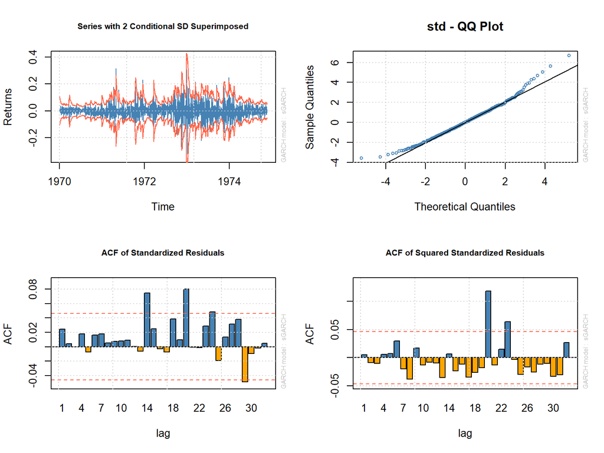

Diagnostyka modelu GARCH(1,1)

```r
par(mfrow = c(2, 2))
plot(garch_fit, which = 1)
plot(garch_fit, which = 9)
plot(garch_fit, which = 10)
plot(garch_fit, which = 11)
```

```r
par(mfrow = c(1, 1))
```

## 8.3 Porównanie wariantów GARCH

```r
spec_egarch <- ugarchspec(
  variance.model     = list(model = "eGARCH",  garchOrder = c(1, 1)),
  mean.model         = list(armaOrder = arma_order, include.mean = TRUE),
  distribution.model = "std"
)

spec_gjr <- ugarchspec(
  variance.model     = list(model = "gjrGARCH", garchOrder = c(1, 1)),
  mean.model         = list(armaOrder = arma_order, include.mean = TRUE),
  distribution.model = "std"
)

fit_egarch <- ugarchfit(spec_egarch, returns, solver = "hybrid")
fit_gjr    <- ugarchfit(spec_gjr,    returns, solver = "hybrid")

ic_table <- data.frame(
  Model = c("sGARCH(1,1)", "eGARCH(1,1)", "gjrGARCH(1,1)"),
  AIC = c(infocriteria(garch_fit)[1],
          infocriteria(fit_egarch)[1],
          infocriteria(fit_gjr)[1]),
  BIC = c(infocriteria(garch_fit)[2],
          infocriteria(fit_egarch)[2],
          infocriteria(fit_gjr)[2])
)

kable(ic_table, digits = 4,
      caption = "Porównanie modeli GARCH wg kryteriów informacyjnych",
      booktabs = TRUE)
```

Porównanie modeli GARCH wg kryteriów informacyjnych

| Model | AIC | BIC |
| --- | --- | --- |
| sGARCH(1,1) | -3.546 | -3.5153 |
| eGARCH(1,1) | -3.554 | -3.5202 |
| gjrGARCH(1,1) | -3.545 | -3.5112 |